# SES Round 1 (not pilot)

Benny deMayo

1/9/2020

Our aim here is to take a closer look at the data obtained in the latest round of WebCDI data collection. This code has a lot of terrible style and redundancy. Sorry everyone.

```r
#accepts: path to directory of WebCDI summary score files
#returns: aggregated cleaned data
readInWebCDI <- function(directory) {
  clean_data <-
    directory %>%
    map_df(~read_csv(., col_types = cols(.default = col_character()))) %>% #read in columns as a character
    mutate_at(
      .funs = ~case_when(
        str_detect(., "<") ~ 1, #get rid of entries that have 'less than' signs in them
        TRUE ~ as.numeric(.)
      ),
      .vars = vars(contains("Percentile"))
    ) %>%
    mutate_at(
      .funs = ~as.numeric(.), #turn all the quantitative columns back into numeric
      .vars =
       vars(
          which(colnames(.) == "benchmark age"):ncol(.)
        )
    )
    return(clean_data)
}

readInWebCdiSummary <- function(summary_df) {
  clean_data <-
    read_csv(summary_df, col_types = cols(.default = col_character())) %>%
    mutate_at(
      .funs = ~case_when(
        str_detect(., "<") ~ 1, #get rid of entries that have 'less than' signs in them
        TRUE ~ as.numeric(.)
      ),
      .vars = vars(contains("Percentile"))
    ) %>%
    mutate_at(
      .funs = ~as.numeric(.), #turn all the quantitative columns back into numeric
      .vars =
       vars(
          which(colnames(.) == "benchmark age"):ncol(.)
        )
    )
}

ses_pilot_raw <- readInWebCdiSummary(ses_pilot_wg)
ses_round_1_wg_raw <-  readInWebCdiSummary(ses_round_1_aggregated_wg)
ses_round_1_ws_raw <-  readInWebCdiSummary(ses_round_1_aggregated_ws)

pilot_n <- ses_pilot_raw %>% nrow()
ses_round_1_wg_n <- ses_round_1_wg_raw %>% nrow()
ses_round_1_ws_n <- ses_round_1_ws_raw %>% nrow()

total_n <- pilot_n + ses_round_1_wg_n + ses_round_1_ws_n

#raw_completed denotes dfs that have data of only completed admins but aren't filtered for exclusions
ses_pilot_raw_completed <- ses_pilot_raw %>% filter(completed == TRUE)
ses_wg_raw_completed <- ses_round_1_wg_raw %>% filter(completed == TRUE)
ses_ws_raw_completed <- ses_round_1_ws_raw %>% filter(completed == TRUE)

pilot_n_completed <- ses_pilot_raw_completed %>% nrow()
ses_round_1_wg_n_completed <- ses_wg_raw_completed %>% nrow()
ses_round_1_ws_n_completed <- ses_ws_raw_completed %>% nrow()

total_completed_n <-
  nrow(ses_pilot_raw_completed) +
  nrow(ses_wg_raw_completed) +
  nrow(ses_ws_raw_completed)
```

The total amount of participants who created records (i.e., clicked the Facebook link across all three studies) was 2404; the total amount of participants who completed the survey was 444.

##Exclusions

Here we report on how many participants were excluded from the sample for various reasons.

```r
filterBirthweight <- function(data) {
  clean_data <-
    data %>%
    mutate_at(
      .vars = c("due_date_diff", "birth_weight_lb"),
      .funs = ~as.numeric(.)
    ) %>%
    mutate_at(
      .vars = c("due_date_diff"),
      .funs = ~case_when(
        is.na(.) ~ 0, #turn non-NA's in this column into zeros
        TRUE ~ .
      )
    ) %>%
    mutate(premature = due_date_diff >= 4 & birth_weight_lb < 5.5) %>%
    filter(premature == FALSE)

  return(clean_data)
}

filterMultilingual <- function(data) {
  clean_data <-
    data %>%
    mutate_at(
      .vars = c("language_days_per_week", "language_hours_per_day"),
      .funs = ~as.numeric(.)
    ) %>%
    mutate(
      language_hours_per_week = language_days_per_week * language_hours_per_day
    ) %>%
    filter(is.na(language_hours_per_week) | language_hours_per_week <= 16)
}

filterVision <- function(data) {
  clean_data <-
    data %>%
    filter(
      hearing_loss_boolean != "1" | is.na(hearing_loss_boolean),
      vision_problems_boolean != "1" | is.na(vision_problems_boolean)
    )

  return(clean_data)
}
```

### Filtering out participants because of birthweight and premature births.

```r
ses_pilot_birthweights <-
  ses_pilot_raw_completed %>%
  filterBirthweight()

ses_pilot_birthweights_loss <- pilot_n_completed - nrow(ses_pilot_birthweights)

ses_round_1_wg_birthweights <-
  ses_wg_raw_completed %>%
  filterBirthweight()

ses_round_1_wg_birthweights_loss <-
  ses_round_1_wg_n_completed - nrow(ses_round_1_wg_birthweights)

ses_round_1_ws_birthweights <-
  ses_ws_raw_completed %>%
  filterBirthweight()

ses_round_1_ws_birthweights_loss <-
  ses_round_1_ws_n_completed - nrow(ses_round_1_ws_birthweights)

total_birthweight_loss <-
  ses_pilot_birthweights_loss +
  ses_round_1_wg_birthweights_loss +
  ses_round_1_ws_birthweights_loss
```

### Filtering out participants due to multilingual home environments.

```r
ses_pilot_multi <-
  ses_pilot_raw_completed %>%
  filterMultilingual()

ses_pilot_multi_loss <- pilot_n_completed - nrow(ses_pilot_multi)

ses_round_1_wg_multi <-
  ses_wg_raw_completed %>%
  filterMultilingual()

ses_round_1_wg_multi_loss <-
  ses_round_1_wg_n_completed - nrow(ses_round_1_wg_multi)

ses_round_1_ws_multi <-
  ses_ws_raw_completed %>%
  filterMultilingual()

ses_round_1_ws_multi_loss <-
  ses_round_1_ws_n_completed - nrow(ses_round_1_ws_multi)

total_multi_loss <-
  ses_pilot_multi_loss +
  ses_round_1_wg_multi_loss +
  ses_round_1_ws_multi_loss
```

### Filtering out participants due to hearing and/or vision loss.

```r
ses_pilot_vision <-
  ses_pilot_raw_completed %>%
  filterVision()

ses_pilot_vision_loss <- pilot_n_completed - nrow(ses_pilot_vision)

ses_round_1_wg_vision <-
  ses_wg_raw_completed %>%
  filterVision()

ses_round_1_wg_vision_loss <-
  ses_round_1_wg_n_completed - nrow(ses_round_1_wg_vision)

ses_round_1_ws_vision <-
  ses_ws_raw_completed %>%
  filterVision()

ses_round_1_ws_vision_loss <-
  ses_round_1_ws_n_completed - nrow(ses_round_1_ws_vision)

total_vision_loss <-
  ses_pilot_vision_loss +
  ses_round_1_wg_vision_loss +
  ses_round_1_ws_vision_loss
```

```r
ses_pilot <-
  ses_pilot_raw %>%
  filter(completed == TRUE) %>%
  filterBirthweight() %>%
  filterMultilingual() %>%
  filterMultilingual()

ses_pilot_total_loss <- pilot_n_completed - nrow(ses_pilot)

ses_wg <-
  ses_round_1_wg_raw %>%
  filter(completed == TRUE) %>%
  filterBirthweight() %>%
  filterMultilingual() %>%
  filterMultilingual()

ses_wg_total_loss <- ses_round_1_wg_n_completed - nrow(ses_wg)

ses_ws <-
  ses_round_1_ws_raw %>%
  filter(completed == TRUE) %>%
  filterBirthweight() %>%
  filterMultilingual() %>%
  filterMultilingual()

ses_ws_total_loss <- ses_round_1_ws_n_completed - nrow(ses_ws)

total_loss <-
  ses_pilot_total_loss +
  ses_wg_total_loss +
  ses_ws_total_loss
```

### Exclusion because of biological/environmental factors

After only considering participants who finished the survey, 8 participants were excluded from the sample due to self-reported premature birth or low birthweight. An additional 34 participants were excluded because of self-reported exposure to more than 16 hours per week of a language other than English, and 6 participants were excluded due to self-reported vision or hearing problems in their children.

In sum, 40 participants were excluded because of biological or environmental factors.

```r
getCompletionInterval <- function(data) {
  clean_data <-
    data %>%
    mutate(
      completion_interval = lubridate::interval(created_date, last_modified),
      completion_time = completion_interval / lubridate::minutes()
    )

  return(clean_data)
}


pilot_ct_age_raw <-
  ses_pilot_raw_completed %>%
  getCompletionInterval() %>%
  select(subject_id, completion_time, `Words Understood`, age, study_name) %>%
  mutate(age = as.numeric(age), instrument = "WG") %>%
  rename(total = `Words Understood`) #change variable name so that we can bind with other df

wg_ct_age_raw <-
  ses_wg_raw_completed %>%
  getCompletionInterval() %>%
  select(subject_id, completion_time, `Words Understood`, age, study_name) %>%
  mutate(age = as.numeric(age), instrument = "WG") %>%
  rename(total = `Words Understood`) #change variable name so that we can bind with other df

ws_ct_age_raw <-
  ses_ws_raw_completed %>%
  getCompletionInterval() %>%
  select(subject_id, completion_time, `Total Produced`, age, study_name) %>%
  mutate(age = as.numeric(age), instrument = "WS") %>%
  rename(total = `Total Produced`)  #change variable name so that we can bind with other df

aggregate_ct_age_raw_completed <-
  bind_rows(pilot_ct_age_raw, wg_ct_age_raw, ws_ct_age_raw) %>%
  mutate(
    quick_completion = completion_time <= 6
  ) %>%
  count(quick_completion)

quick_completed_raw <- aggregate_ct_age_raw_completed %>% slice(2) %>% pull(n)

normally_completed_raw <-
  aggregate_ct_age_raw_completed %>%
  slice(1) %>%
  pull(n)
```

Before any exclusions (other than those for completeness of the survey), 204 out of 444 participants, or a proportion of 0.4594595 completed the survey too quickly.

Below, I show the same figures once accounting for the previously mentioned exclusion criteria.

```r
pilot_ct_age <-
  ses_pilot %>%
  getCompletionInterval() %>%
  select(subject_id, completion_time, `Words Understood`, age, study_name) %>%
  mutate(age = as.numeric(age), instrument = "WG") %>%
  rename(total = `Words Understood`) #change variable name so that we can bind with other df

wg_ct_age <-
  ses_wg %>%
  getCompletionInterval() %>%
  select(subject_id, completion_time, `Words Understood`, age, study_name) %>%
  mutate(age = as.numeric(age), instrument = "WG") %>%
  rename(total = `Words Understood`) %>%  #change variable name so that we can bind with other df
  bind_rows(pilot_ct_age)

ws_ct_age <-
  ses_ws %>%
  getCompletionInterval() %>%
  select(subject_id, completion_time, `Total Produced`, age, study_name) %>%
  mutate(age = as.numeric(age), instrument = "WS") %>%
  rename(total = `Total Produced`)  #change variable name so that we can bind with other df

aggregate_ct_age_completed <-
  bind_rows(pilot_ct_age, wg_ct_age, ws_ct_age) %>%
  mutate(
    quick_completion = completion_time <= 6
  )

aggregate_ct_age_count <-
  aggregate_ct_age_completed %>%
  count(quick_completion)

quick_completed <- aggregate_ct_age_count %>% slice(2) %>% pull(n)

normally_completed <-
  aggregate_ct_age_count %>%
  slice(1) %>%
  pull(n)
```

When we *do* account for exclusions, the proportions change very slightly: 207 out of 473, or 0.4376321 of participants, completed the survey in 6 minutes or fewer, which is criteria for exclusion. Let’s look a little bit at how completion time is related to age.

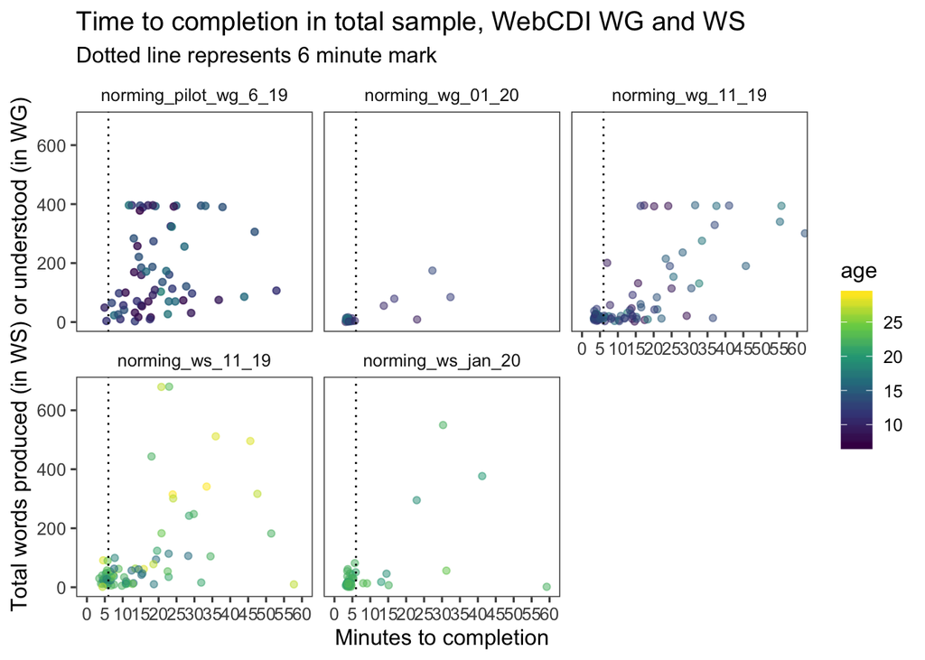

```r
survey_maxes <-
  tibble(
    instrument = c("WG", "WS"),
    max = c(396, 680)
  )

aggregate_ct_age_completed %>%
  ggplot(aes(completion_time, total, color = age)) +
  facet_wrap(~ study_name) +
  geom_jitter(position = position_jitter(width = 0.1), alpha = 0.5) +
  coord_cartesian(xlim = c(0, 100)) +
  ggthemes::theme_few() +
  scale_color_viridis_c() +
  coord_cartesian(xlim = c(0, 60)) +
  scale_x_continuous(breaks = seq(0, 60, 5)) +
  labs(
    x = "Minutes to completion",
    y = "Total words produced (in WS) or understood (in WG)",
    title = "Time to completion in total sample, WebCDI WG and WS",
    subtitle = "Dotted line represents 6 minute mark"
  ) +
  geom_vline(xintercept = 6, linetype = "dotted")
```

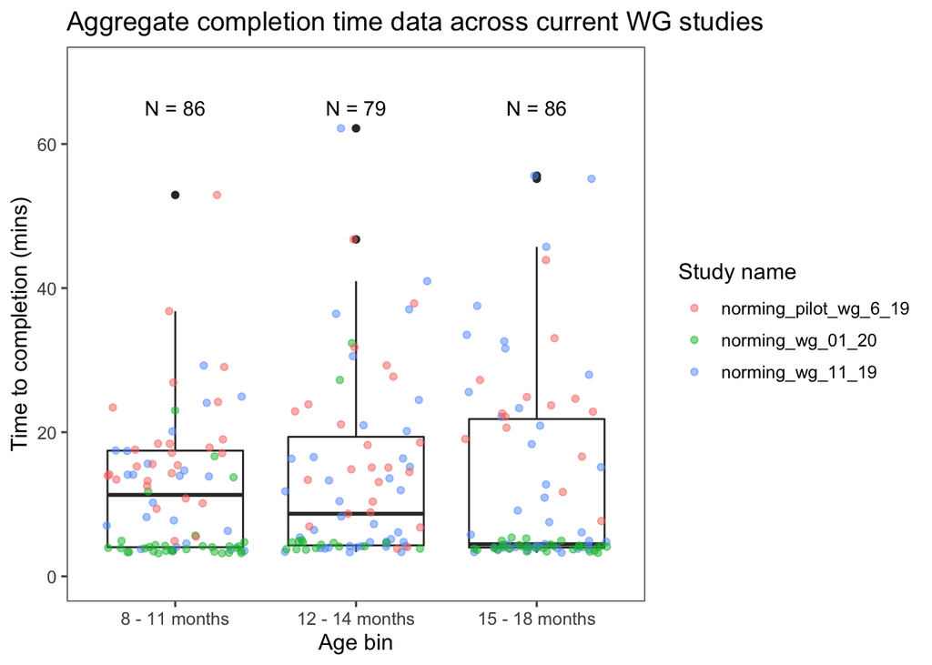

```r
wg_ct_age_cats <-
  wg_ct_age %>%
  filter(age > 7) %>%
  mutate(age_bin = cut_interval(
    age,
    3,
    labels = c("8 - 11 months", "12 - 14 months", "15 - 18 months")
  ))

boxplot_annotations_wg <-
  wg_ct_age_cats %>%
  count(age_bin) %>%
  mutate(label = str_c("N = ", as.character(n)), completion_time = 65)

wg_ct_age_cats %>%
  ggplot(aes(age_bin, completion_time)) +
  geom_boxplot() +
  geom_jitter(aes(color = study_name), alpha = 0.5) +
  geom_text(aes(label = label), data = boxplot_annotations_wg) +
  coord_cartesian(ylim = c(0, 70)) +
  ggthemes::theme_few() +
  labs(
    x = "Age bin",
    y = "Time to completion (mins)",
    title = "Aggregate completion time data across current WG studies",
    color = "Study name"
  )
```

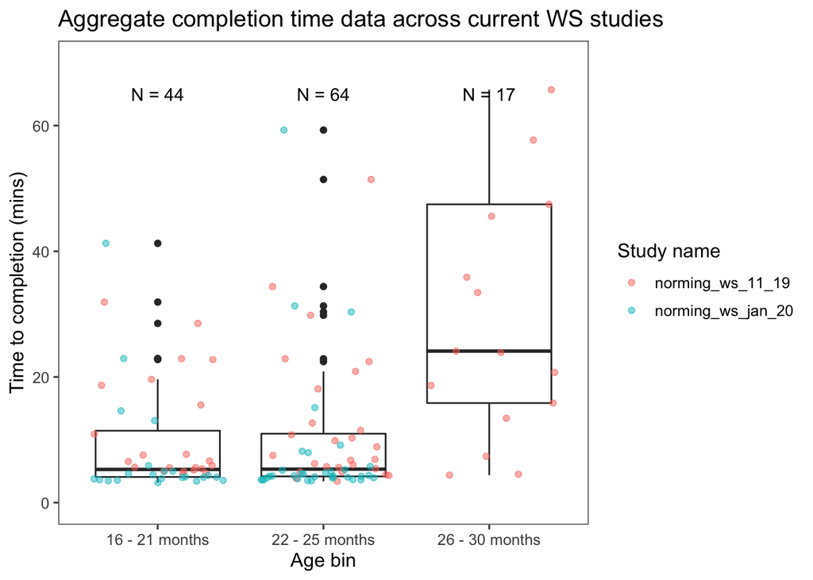

```r
ws_ct_age_cats <-
  ws_ct_age %>%
  filter(age > 16) %>%
  mutate(age_bin = cut_interval(
    age,
    3,
    labels = c("16 - 21 months", "22 - 25 months", "26 - 30 months")
  ))

boxplot_annotations_ws <-
  ws_ct_age_cats %>%
  count(age_bin) %>%
  mutate(label = str_c("N = ", as.character(n)), completion_time = 65)

ws_ct_age_cats %>%
  ggplot(aes(age_bin, completion_time)) +
  geom_boxplot() +
  geom_jitter(aes(color = study_name), alpha = 0.5) +
  geom_text(aes(label = label), data = boxplot_annotations_ws) +
  coord_cartesian(ylim = c(0, 70)) +
  ggthemes::theme_few() +
  labs(
    x = "Age bin",
    y = "Time to completion (mins)",
    title = "Aggregate completion time data across current WS studies",
    color = "Study name"
  )
```

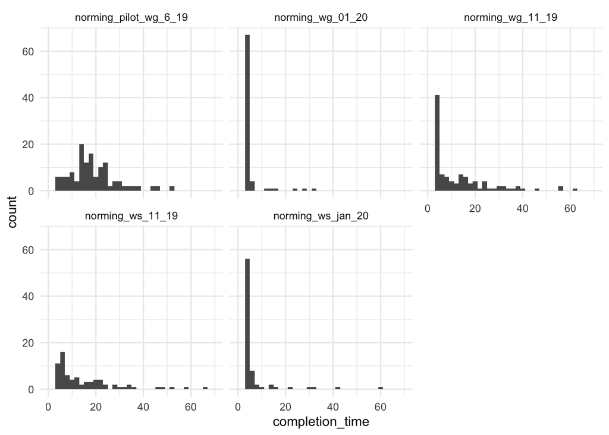

```r
aggregate_ct_age_completed %>%
  ggplot(aes(completion_time)) +
  geom_histogram(position = "dodge", binwidth = 2) +
  facet_wrap(~study_name) +
  coord_cartesian(xlim = c(0, 70)) +
  theme_minimal()
```

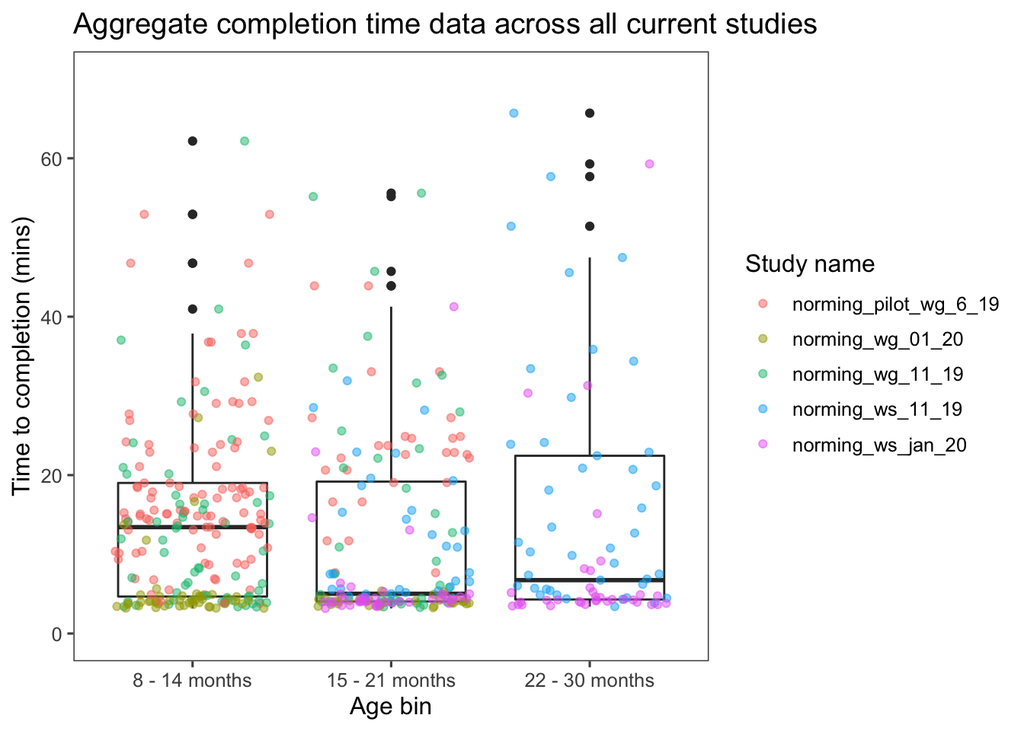

```r
aggregate_ct_age_completed %>%
  mutate(age_bin = cut_interval(
    age,
    3,
    labels = c("8 - 14 months", "15 - 21 months", "22 - 30 months")
  )) %>%
  ggplot(aes(age_bin, completion_time)) +
  geom_boxplot() +
  geom_jitter(aes(color = study_name), alpha = 0.5) +
  coord_cartesian(ylim = c(0, 70)) +
  ggthemes::theme_few() +
  labs(
    x = "Age bin",
    y = "Time to completion (mins)",
    title = "Aggregate completion time data across all current studies",
    color = "Study name"
  )
```

It looks like parents of kids of all ages cheated the system here, unfortunately - no clear patter when looking at this boxplot. Let’s look at some summary statistics:

```r
aggregate_ct_age_completed %>%
  group_by(study_name) %>%
  summarize(
    median_ct = median(completion_time),
    mean_ct = mean(completion_time, na.rm = TRUE),
    min_ct = min(completion_time),
    max_ct = max(completion_time)
  )
```

```
## # A tibble: 5 x 5
##   study_name            median_ct mean_ct min_ct max_ct
##   <chr>                     <dbl>   <dbl>  <dbl>  <dbl>
## 1 norming_pilot_wg_6_19     17.9   135.     3.83  5783.
## 2 norming_wg_01_20           4.07    8.73   3.20   269.
## 3 norming_wg_11_19           8.22   76.1    3.29  5853.
## 4 norming_ws_11_19          11.3    78.3    3.40  3077.
## 5 norming_ws_jan_20          4.28   50.7    3.17  3331.
```

### Participant ethnicities and education levels

A key goal of this project has been to diversify the sample of participants completing WebCDI.

A lot of parents have been filling out this survey really quickly; let’s toss out the ones who have filled it out in fewer than six minutes.

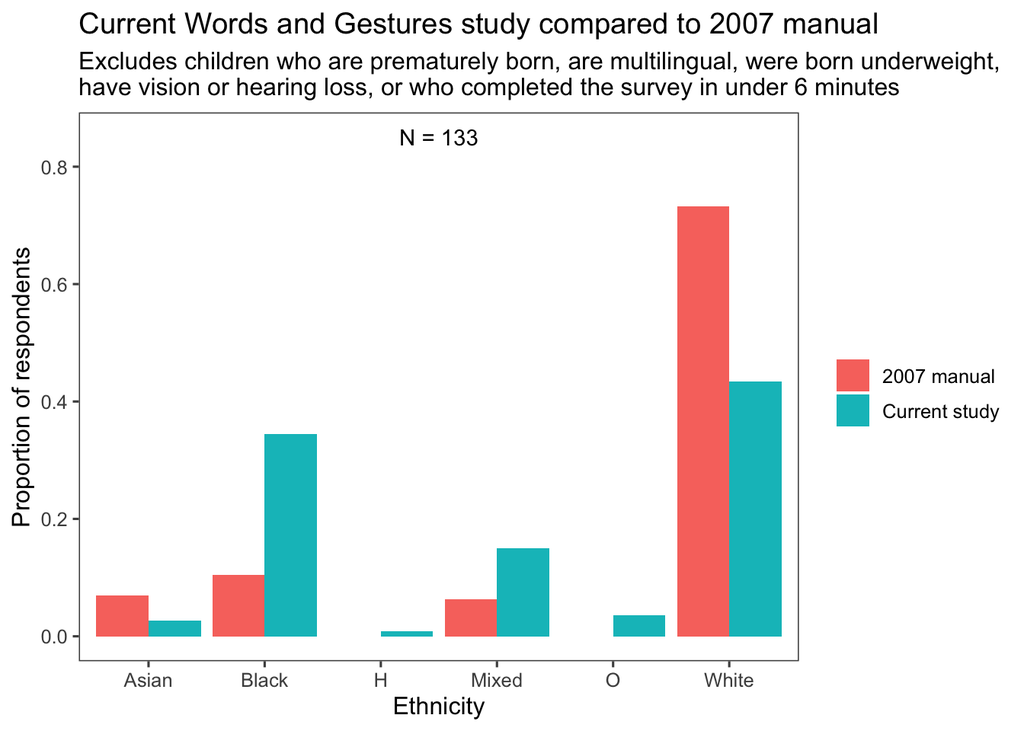

```r
ses_pilot_time_filtered <-
  ses_pilot %>%
  getCompletionInterval() %>%
  filter(completion_time > 6)

ses_wg_time_filtered <-
  ses_wg %>%
  getCompletionInterval() %>%
  filter(completion_time > 6)

ses_ws_time_filtered <-
  ses_ws %>%
  getCompletionInterval() %>%
  filter(completion_time > 6)

getEthnicities <- function(data) {
  clean_data <-
    data %>%
    mutate( #get rid of brackets in ethnicity column
      child_ethnicity = str_replace_all(child_ethnicity, "[^[:upper:]]", "")
    ) %>%
    mutate(
      ethnicity_white = str_detect(child_ethnicity, "W"),
      ethnicity_black = str_detect(child_ethnicity, "B"),
      ethnicity_asian = str_detect(child_ethnicity, "A"),
      ethnicity_native = str_detect(child_ethnicity, "N"),
      ethnicity_other = str_detect(child_ethnicity, "O"),
      ethnicity_mixed = str_length(child_ethnicity) > 1
    )

  old_ethnicity_numbers <-
   tibble(
      ethnicity = c("Asian", "Black", "Mixed", "White"),
      `2007 manual` = c(.069, .105, .063, .733)
    )

  clean_data <-
    clean_data %>%
    mutate( #get rid of brackets in ethnicity column
      child_ethnicity = str_replace_all(child_ethnicity, "[^[:upper:]]", "")
    ) %>%
    mutate(
      ethnicity = case_when(
        str_length(child_ethnicity) > 1 ~ "mixed",
        TRUE ~ child_ethnicity
      ) %>% fct_recode(
        Asian = "A",
        Black = "B",
        Mixed = "mixed",
        White = "W"
      )
    ) %>%
    filter(ethnicity != "") %>%
    select(subject_id, child_ethnicity, ethnicity) %>%
    count(ethnicity) %>%
    mutate(`Current study` = n / sum(n)) %>%
    left_join(
      old_ethnicity_numbers,
      by = c("ethnicity")
    ) %>%
    pivot_longer(
      cols = c(`Current study`, `2007 manual`),
      names_to = "study",
      values_to = "proportion"
    )

  return(clean_data)
}

#df for ethnicity plot
ses_wg_ethnicity <-
  ses_wg %>%
  bind_rows(ses_pilot) %>%
  getCompletionInterval() %>%
  filter(completion_time > 6) %>%
  getEthnicities()

ses_wg_ethnicity_n <-
  nrow(
    ses_wg %>%
    bind_rows(ses_pilot) %>%
    getCompletionInterval() %>%
    filter(completion_time > 6)
  )

ses_wg_ethnicity %>%
  ggplot(aes(ethnicity, proportion, fill = study)) +
  geom_col(position = "dodge") +
  labs(
    x = "Ethnicity",
    y = "Proportion of respondents",
    title = "Current Words and Gestures study compared to 2007 manual",
    subtitle = "Excludes children who are prematurely born, are multilingual, were born underweight,\nhave vision or hearing loss, or who completed the survey in under 6 minutes"
  ) +
  theme_few() +
  theme(legend.title = element_blank()) +
  annotate(
    "text",
    label = str_c("N = ", ses_wg_ethnicity_n),
    x = 3.5,
    y = 0.85,
    hjust = "center"
  )
```

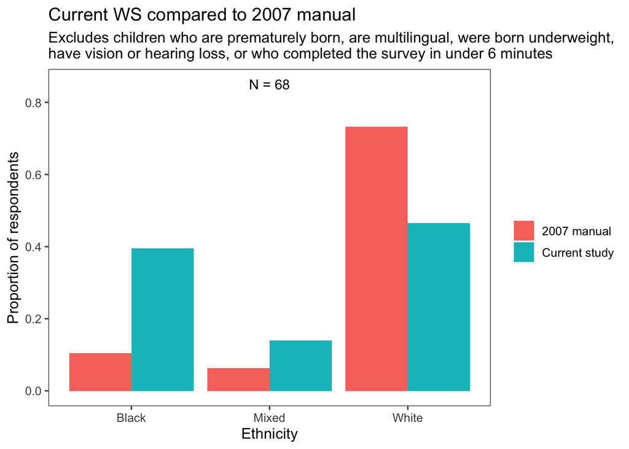

```r
ses_ws_ethnicity <-
  ses_ws %>%
  getCompletionInterval() %>%
  filter(completion_time > 6) %>%
  getEthnicities()

ses_ws_ethnicity_n <-
  ses_ws %>%
  getCompletionInterval() %>%
  filter(completion_time > 6) %>%
  nrow()


ses_ws_ethnicity %>%
  ggplot(aes(ethnicity, proportion, fill = study)) +
  geom_col(position = "dodge") +
  labs(
    x = "Ethnicity",
    y = "Proportion of respondents",
    title = "Current WS compared to 2007 manual",
    subtitle = "Excludes children who are prematurely born, are multilingual, were born underweight,\nhave vision or hearing loss, or who completed the survey in under 6 minutes"
  ) +
  theme_few() +
  theme(legend.title = element_blank()) +
  annotate(
    "text",
    label = str_c("N = ", ses_ws_ethnicity_n),
    x = 2.0,
    y = 0.85,
    hjust = "center"
  )
```

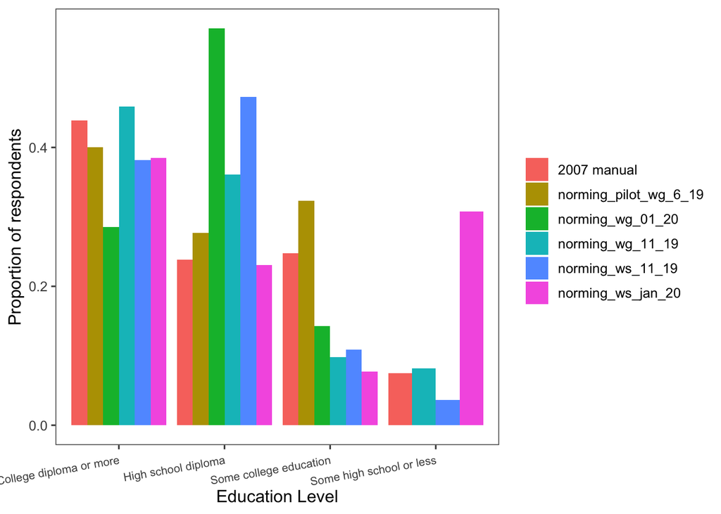

```r
getMaternalEd <- function(data) {
  clean_data <-
    data %>%
    select(subject_id, mother_education, study_name) %>%
    mutate(
      maternal_ed = case_when(
        mother_education <= 11 ~ "Some high school or less",
        mother_education == 12 ~ "High school diploma",
        mother_education %in% seq.int(13, 15) ~
          "Some college education",
        mother_education >= 16 ~ "College diploma or more"
      )
    )
}

aggregate_maternal_ed <-
  bind_rows(
    ses_pilot_time_filtered %>% getMaternalEd(),
    ses_wg_time_filtered %>% getMaternalEd(),
    ses_ws_time_filtered %>% getMaternalEd()
  )

old_props <-
  tibble(
    maternal_ed = c(
      "Some high school or less",
      "High school diploma",
      "Some college education",
      "College diploma or more"
    ),
    study_name = "2007 manual",
    `Study proportion` = c(.075, .2385, .248, .4385)
  )

aggregate_maternal_ed %>%
  count(maternal_ed, study_name) %>%
  group_by(study_name) %>%
  mutate(
    `Study proportion` = n / sum(n)
  ) %>%
  select(-n) %>%
  bind_rows(old_props) %>%
  mutate(
    maternal_ed = fct_relevel(
      maternal_ed,
      "Some high school or less",
      "High school diploma",
      "Some college education",
      "College diploma or more"
    )
  ) %>%
  ggplot(aes(maternal_ed, `Study proportion`, fill = `study_name`)) +
  geom_col(position = "dodge") +
  labs(
    x = "Education Level",
    y = "Proportion of respondents"
  ) +
  theme_few() +
  theme(
    legend.title = element_blank(),
    axis.text.x = element_text(angle = 10, vjust = 0.9, hjust = 1, size = 8),
    axis.title.x = element_text()
  )
```

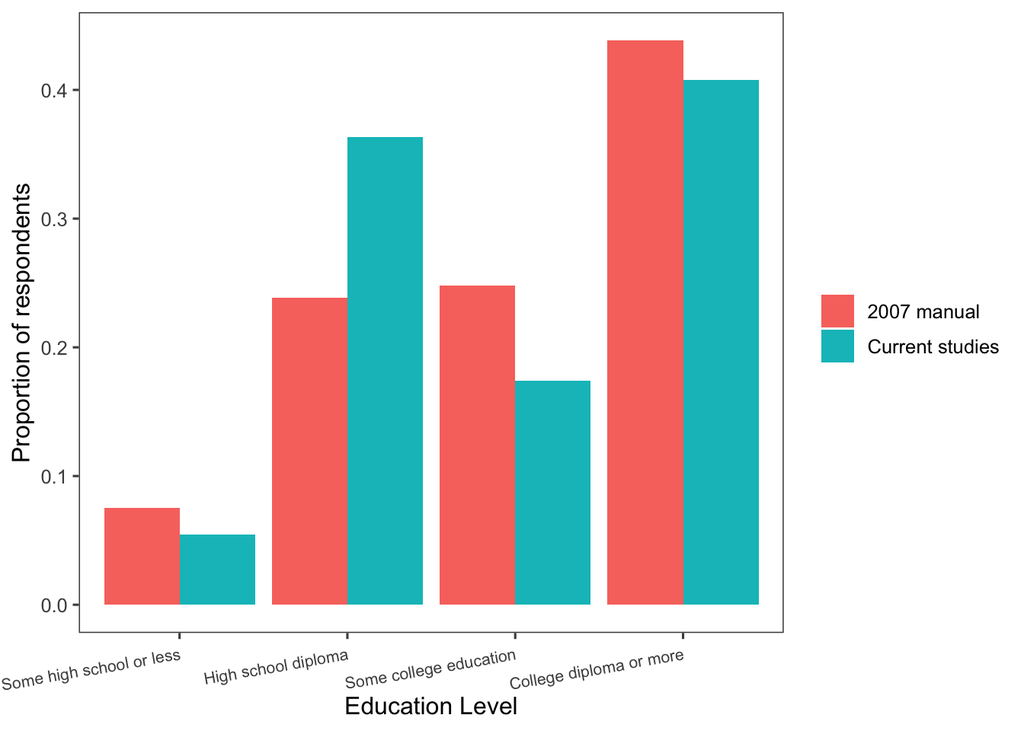

```r
aggregate_maternal_ed %>%
  count(maternal_ed) %>%
  mutate(
    study_name = "Current studies",
    `Study proportion` = n / sum(n)
  ) %>%
  select(-n) %>%
  bind_rows(old_props) %>%
  mutate(
    maternal_ed = fct_relevel(
      maternal_ed,
      "Some high school or less",
      "High school diploma",
      "Some college education",
      "College diploma or more"
    )
  ) %>%
  ggplot(aes(maternal_ed, `Study proportion`, fill = `study_name`)) +
  geom_col(position = "dodge") +
  labs(
    x = "Education Level",
    y = "Proportion of respondents"
  ) +
  theme_few() +
  theme(
    legend.title = element_blank(),
    axis.text.x = element_text(angle = 10, vjust = 0.9, hjust = 1, size = 8),
    axis.title.x = element_text()
  )
```

### Word production and comprehension (filtered datasets)

#### Maternal education and production and comprehension

Here, we take a closer look at production and comprehension data as they relate to maternal education of child participants.

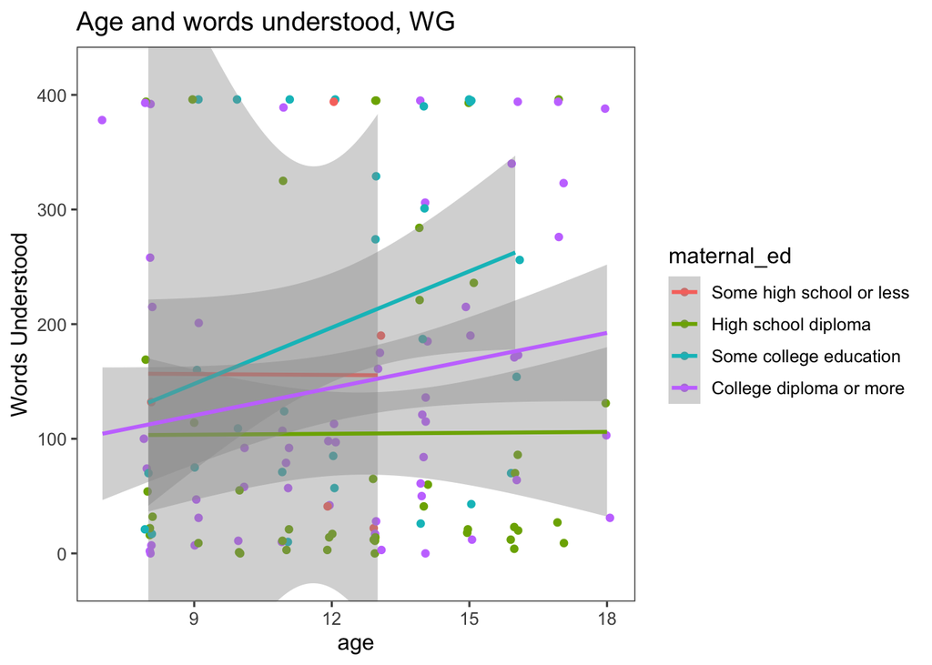

```r
all_wg_time_filtered <-
  ses_pilot_time_filtered %>%
  bind_rows(ses_wg_time_filtered)




wg_maternal_ed <-
  bind_rows(
    ses_pilot_time_filtered %>% getMaternalEd(),
    ses_wg_time_filtered %>% getMaternalEd()
  ) %>%
  left_join(
    all_wg_time_filtered %>%
      select(subject_id, study_name, age, `Words Understood`, `Words Produced`),
    by = c("study_name", "subject_id")
  ) %>%
  mutate_at(
    .funs = ~case_when(
        is.na(.) ~ 0, #get rid of entries that have 'less than' signs in them
        TRUE ~ as.numeric(.)
      ),
      .vars = vars(contains("Words"))
  ) %>%
  mutate(
    age = as.numeric(age),
    maternal_ed = fct_relevel(
      .f = maternal_ed,
      c(
        "Some high school or less",
        "High school diploma",
        "Some college education",
        "College diploma or more"
      )
    )
  )

ws_maternal_ed <-
  ses_ws_time_filtered %>%
  getMaternalEd() %>%
  left_join(
    ses_ws_time_filtered %>%
      select(subject_id, study_name, age, `Total Produced`),
    by = c("study_name", "subject_id")
  ) %>%
  mutate_at(
    .funs = ~case_when(
        is.na(.) ~ 0, #get rid of entries that have 'less than' signs in them
        TRUE ~ as.numeric(.)
      ),
      .vars = vars(contains("Words"))
  ) %>%
  mutate(
    age = as.numeric(age),
    maternal_ed = fct_relevel(
      .f = maternal_ed,
      c(
        "Some high school or less",
        "High school diploma",
        "Some college education",
        "College diploma or more"
      )
    )
  )

wg_maternal_ed %>%
  ggplot(aes(age, `Words Understood`, color = maternal_ed)) +
  geom_jitter(position = position_jitter(width = 0.1, height = 0)) +
  geom_smooth(method = "lm", level = .9) +
  coord_cartesian(ylim = c(-20, 420)) +
  ggthemes::theme_few() +
  labs(title = "Age and words understood, WG")
```

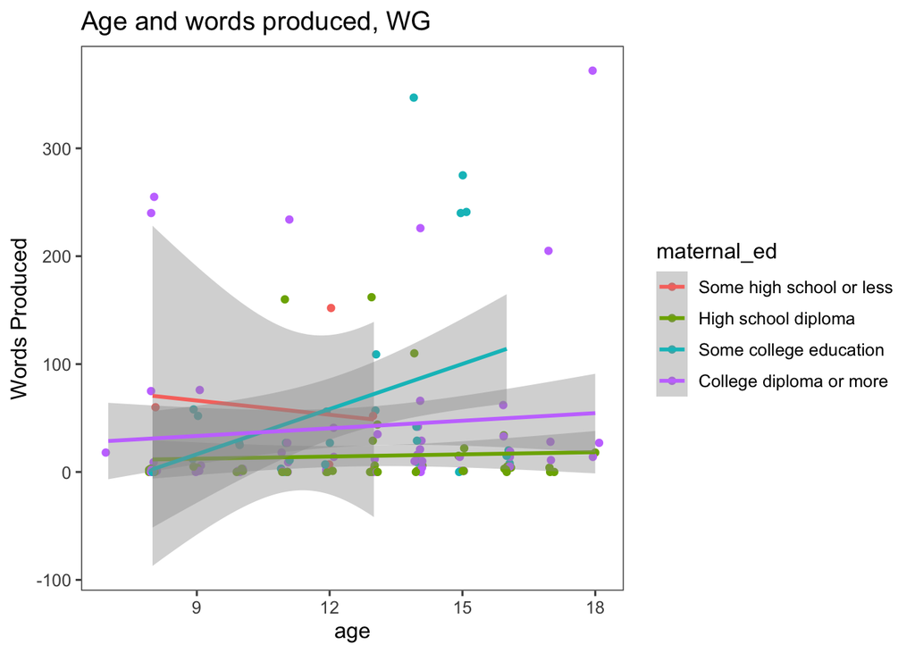

```r
wg_maternal_ed %>%
  ggplot(aes(age, `Words Produced`, color = maternal_ed)) +
  geom_jitter(position = position_jitter(width = 0.1, height = 0)) +
  geom_smooth(method = "lm", level = .9) +
  ggthemes::theme_few() +
  labs(title = "Age and words produced, WG")
```

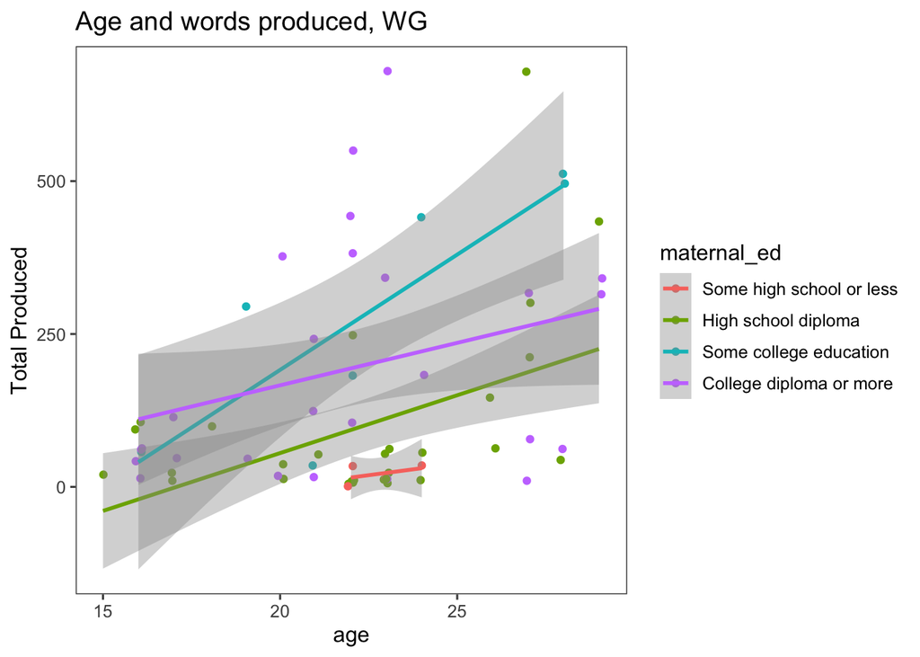

```r
ws_maternal_ed %>%
  ggplot(aes(age, `Total Produced`, color = maternal_ed)) +
  geom_jitter(position = position_jitter(width = 0.1, height = 0)) +
  geom_smooth(method = "lm", level = .9) +
  ggthemes::theme_few() +
  labs(title = "Age and words produced, WG")
```